# Quantitative Methods for HIV Researchers

Base R Graphics

Janice M. McCarthy, Modified Richard Barfield

October 27, 2022

# R Graphics

Ggplot2 is the best way to make pretty plots in R. Sometimes, however, we just want a quick peek at something. R base graphics can come in handy in these situations. We’ll look at some base R graphics first, then move on to ggplot2. (This will also guarantee that you will appreciate the beauty of ggplot2.)

## Base Graphics

Base graphics come right out of the box, without loading any packages. The `plot` command is used to draw 2-d plots.

### Scatter plot

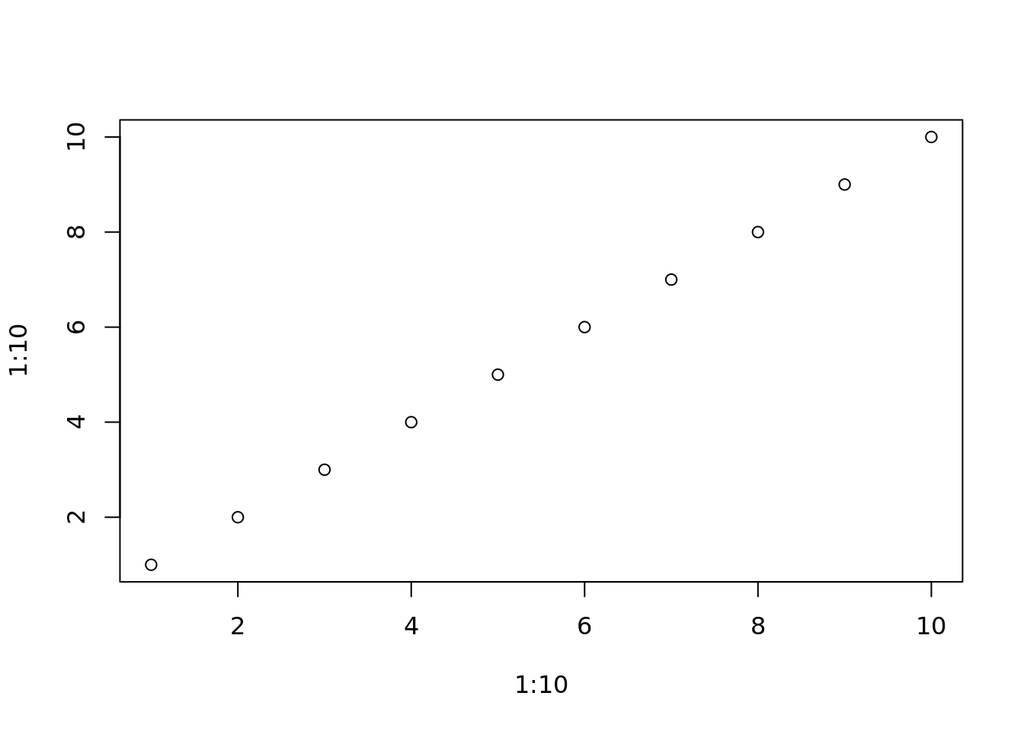

```r
set.seed(12345)
plot(1:10, 1:10)
```

#### Marker symbols

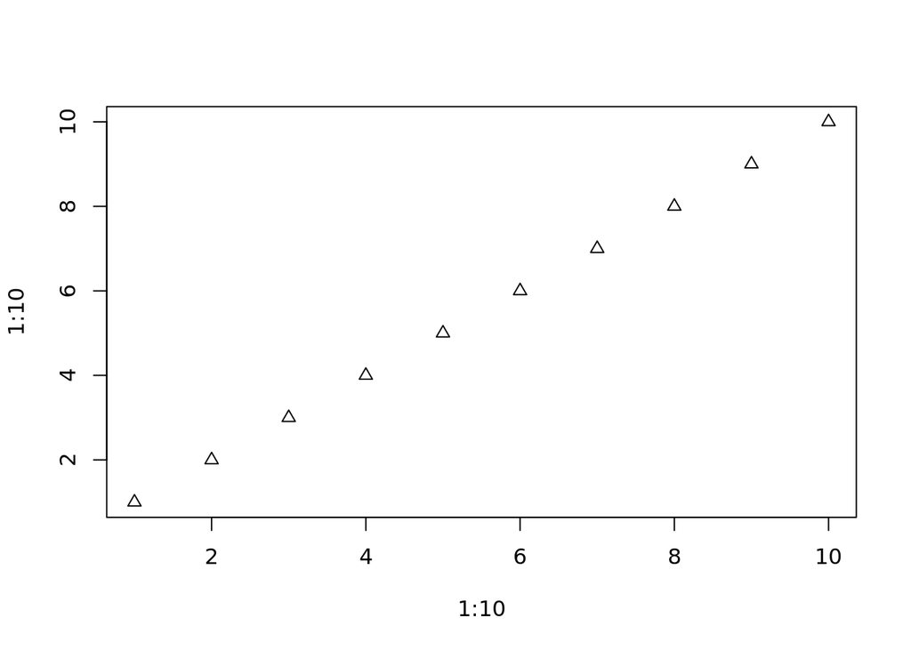

```r
plot(1:10, 1:10, pch=2)
```

#### Marker size

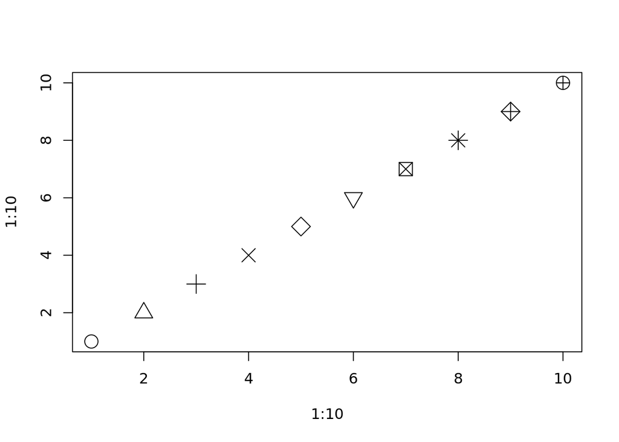

```r
plot(1:10, 1:10, pch=1:10, cex=2)
```

#### Marker colors

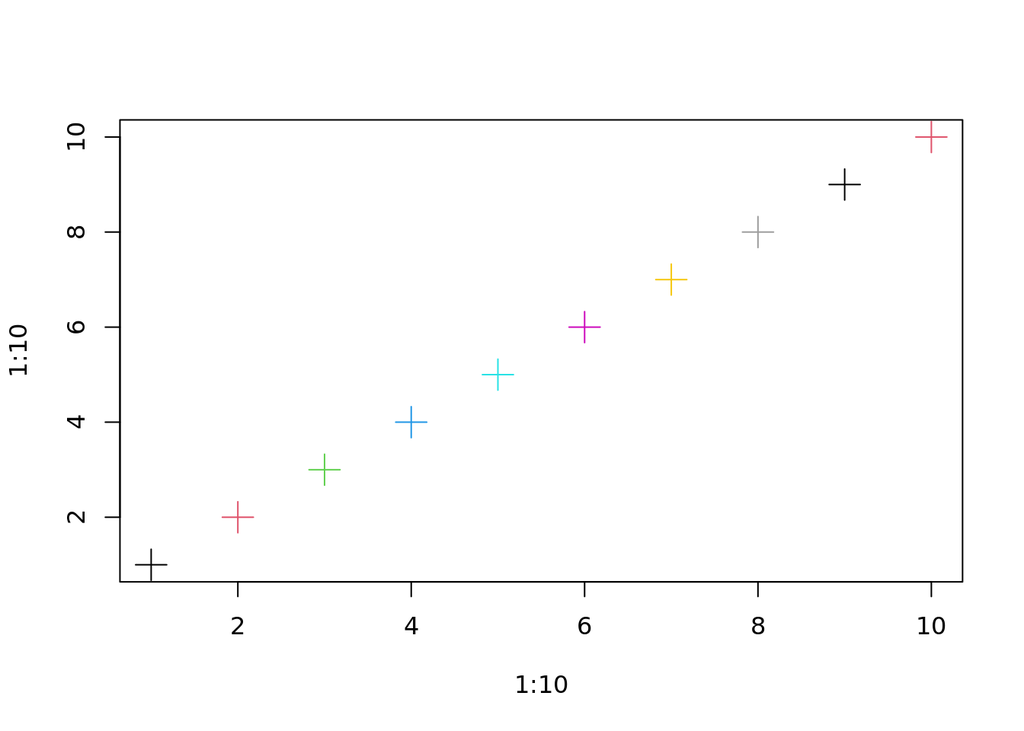

```r
plot(1:10, 1:10, pch=3, cex=2, col=1:10)
```

#### Adding text labels

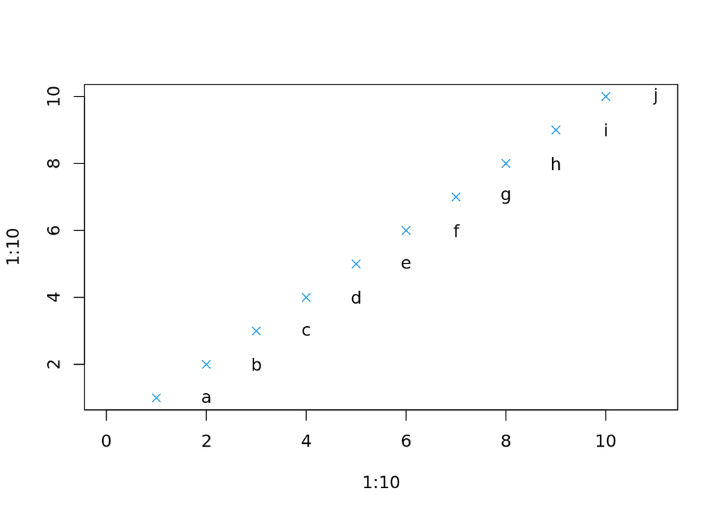

```r
plot(1:10, 1:10, pch=4, col=4, xlim=c(0, 11))
text(1:10+1, 1:10, letters[1:10])
```

### Line plot

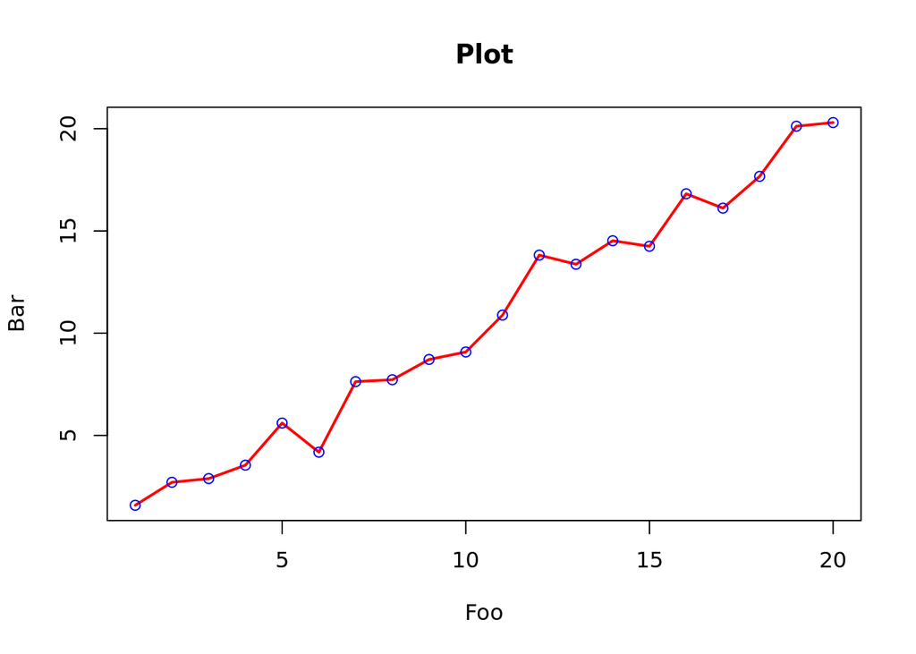

```r
# Generate random data set to plot
n <- 20
x <- 1:n
y <- x + rnorm(n)  # adds 'errors' from the standard normal distribution

plot(x, y, type="l", lty=1, lwd=2, col="red",
     main="Plot", xlab="Foo", ylab="Bar")
points(x, y, col="blue")
```

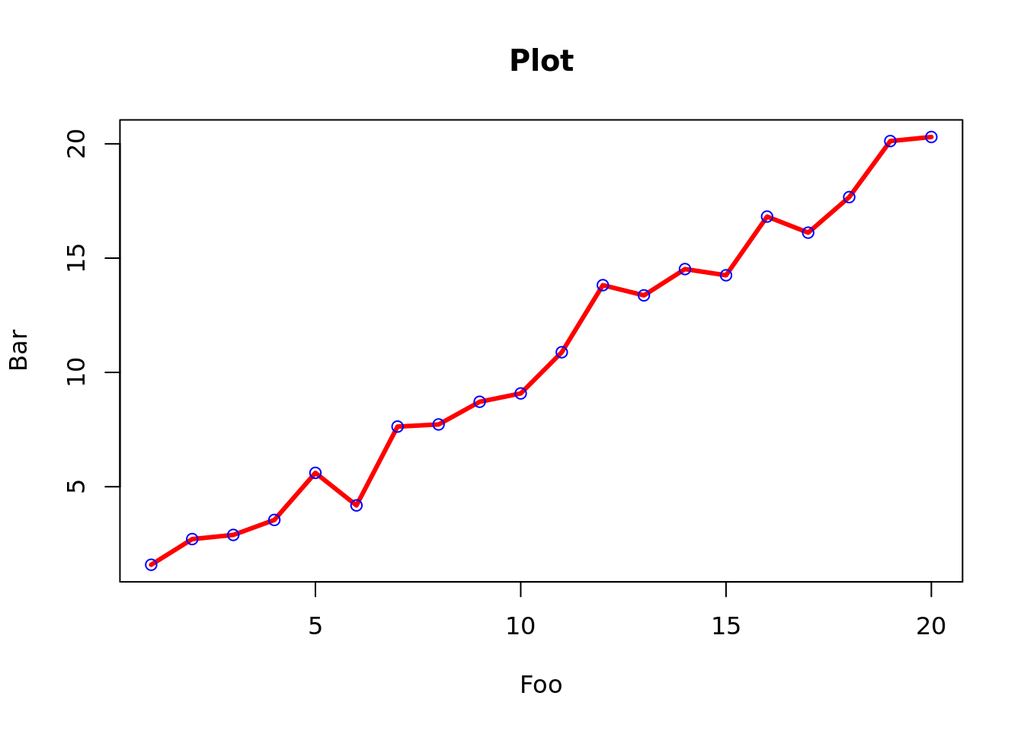

```r
plot(x, y, type="l", lty=1, lwd=3, col="red",
     main="Plot", xlab="Foo", ylab="Bar")
points(x, y, col="blue")
```

Note that the function `points` adds points to the current plot. A new `plot` command will draw another plot. The function `abline` behaves similarly.

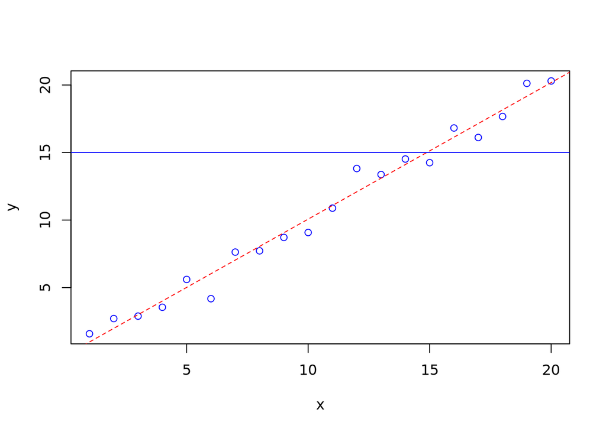

```r
m <- lm(y ~ x)   # linear fit of generated data.


plot(x, y, col="blue")
abline(m, col="red", lty="dashed") # note that we are giving the function abline a fit object.

abline(h=15,col="blue")
```

```r
# h horizontal
```

We can put multiple plots on the same axes:

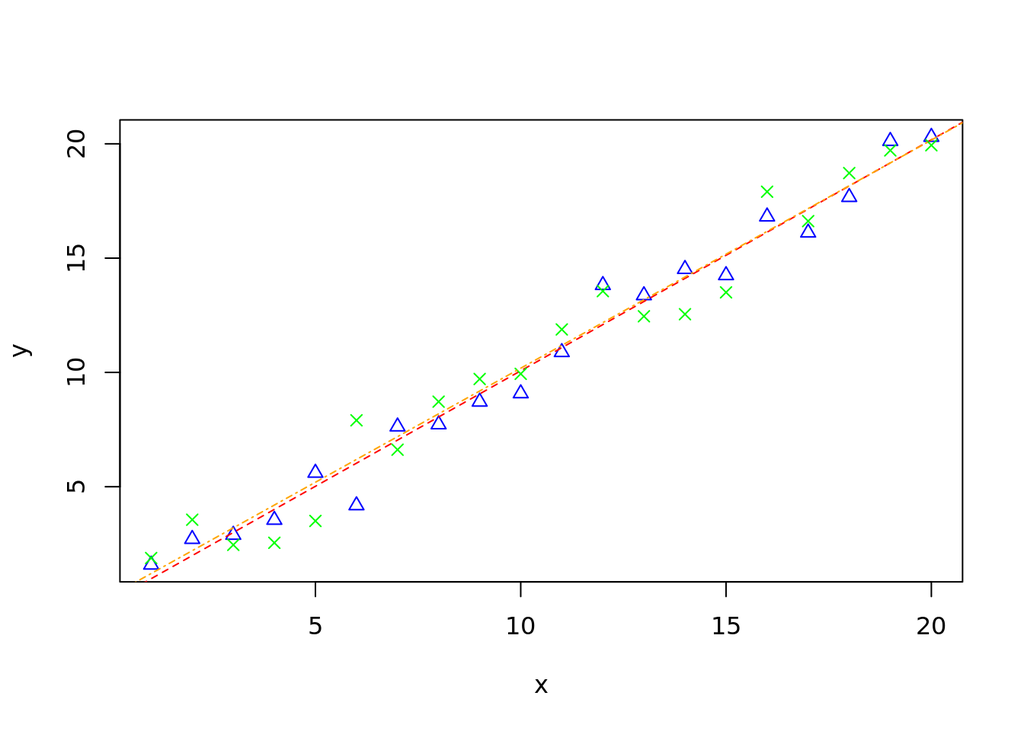

```r
m <- lm(y ~ x)

plot(x, y, col="blue", pch=2)
abline(m, col="red", lty="dashed")

y <- x + rnorm(10, mean = 0.1)
m <- lm(y ~ x)

points(x, y, col="green", pch=4)
abline(m, col="orange", lty=4)
```

### Histogram

This is probably the most useful base graphics function.

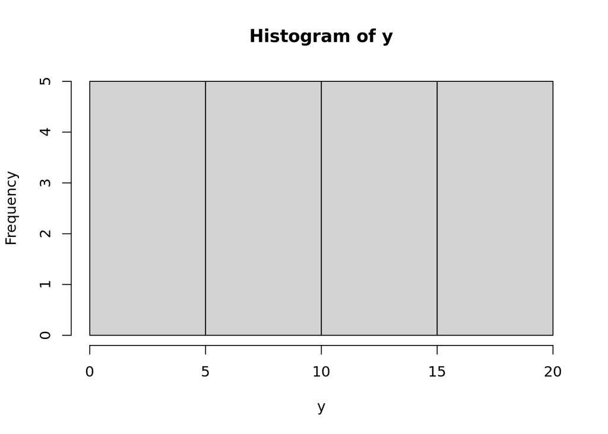

```r
hist(y)
```

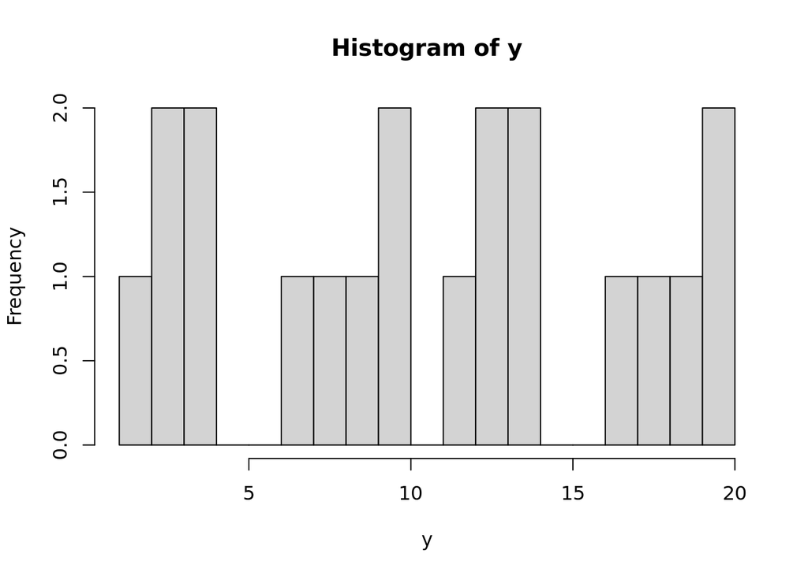

```r
hist(y, breaks = 15)
```

### Barplot

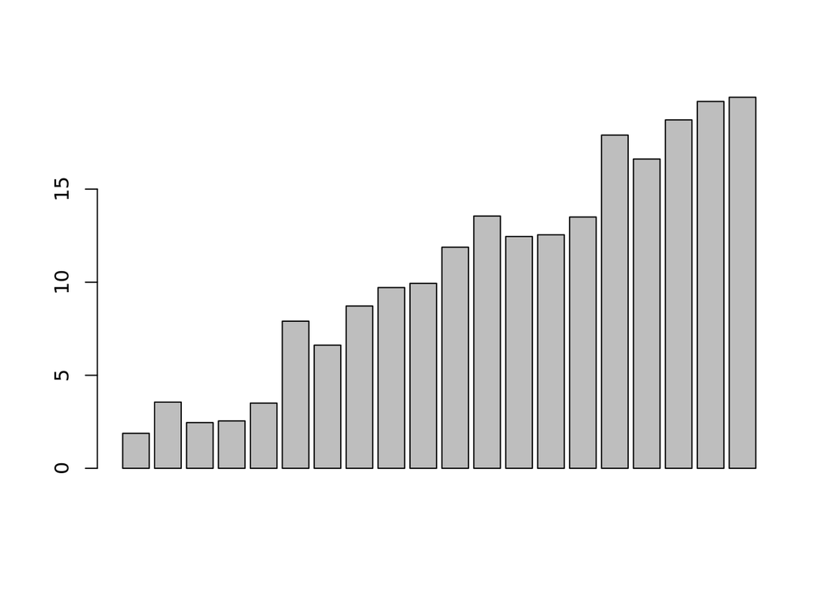

```r
barplot(y)
```

```r
g <- sample(1:3, n, replace=T)
z <- rnorm(n)

gl <-sample(LETTERS[1:3], n, replace=T)
```

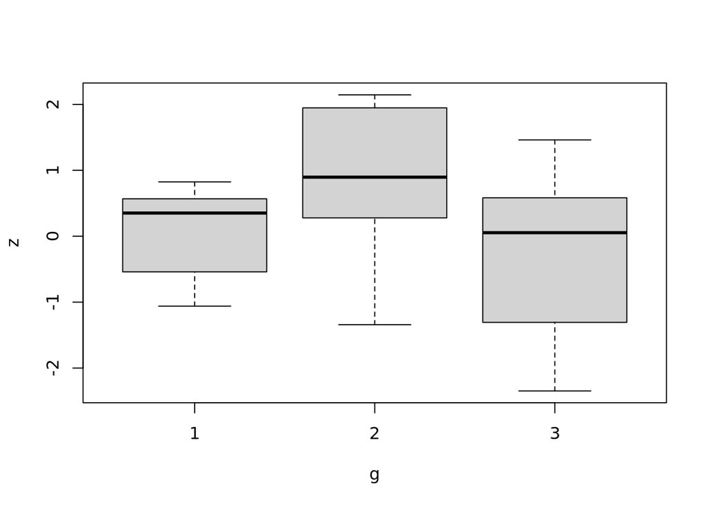

```r
boxplot(z ~ g)
```

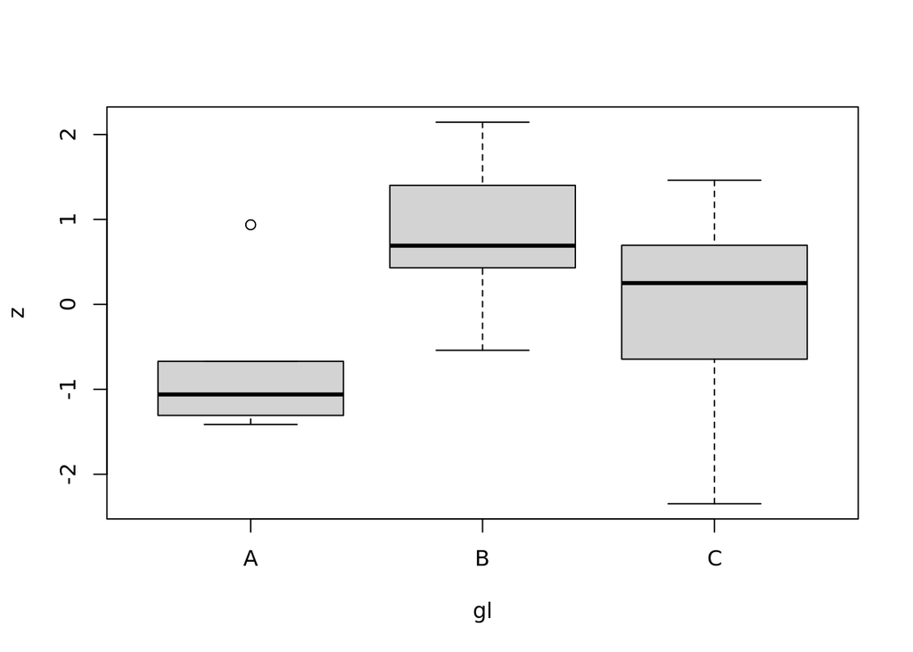

```r
boxplot(z~gl)
```

### QQ plots

QQ plots are quantile-quantile plots. Quantiles are just cut points for what values a distribution achieves a particular probability (e.g. quartiles would break a distribution into 4ths). The most common quantiles are percentiles, where a distribution is broken into 100 pieces. A qq plot plots the observed quantiles in the data against a known distribution (usually the normal distribution). If the data comes from the known distribution, we would expect the quantiles to lie on the diagonal $x = y$.

First, let’s generate 100 values from the standard normal.

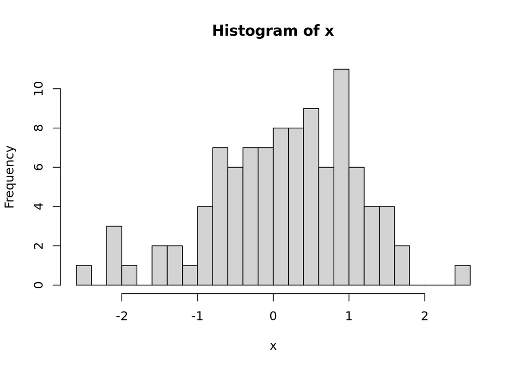

```r
x <- rnorm(100)

hist(x, breaks = 20)
```

We can see from the histogram that this looks approximately normal. The qq plot gives a more quantitative comparison, because each quantile is compared.

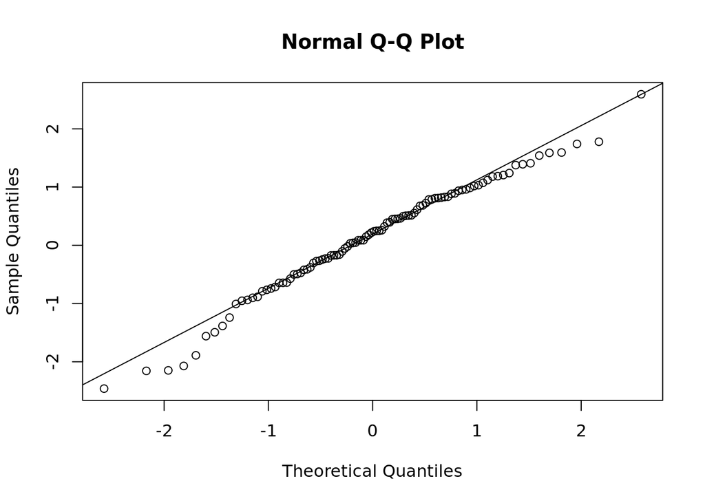

```r
qqnorm(x)
qqline(x)
```

If we generate values from a different distribution, we should see a difference in the qq plot.

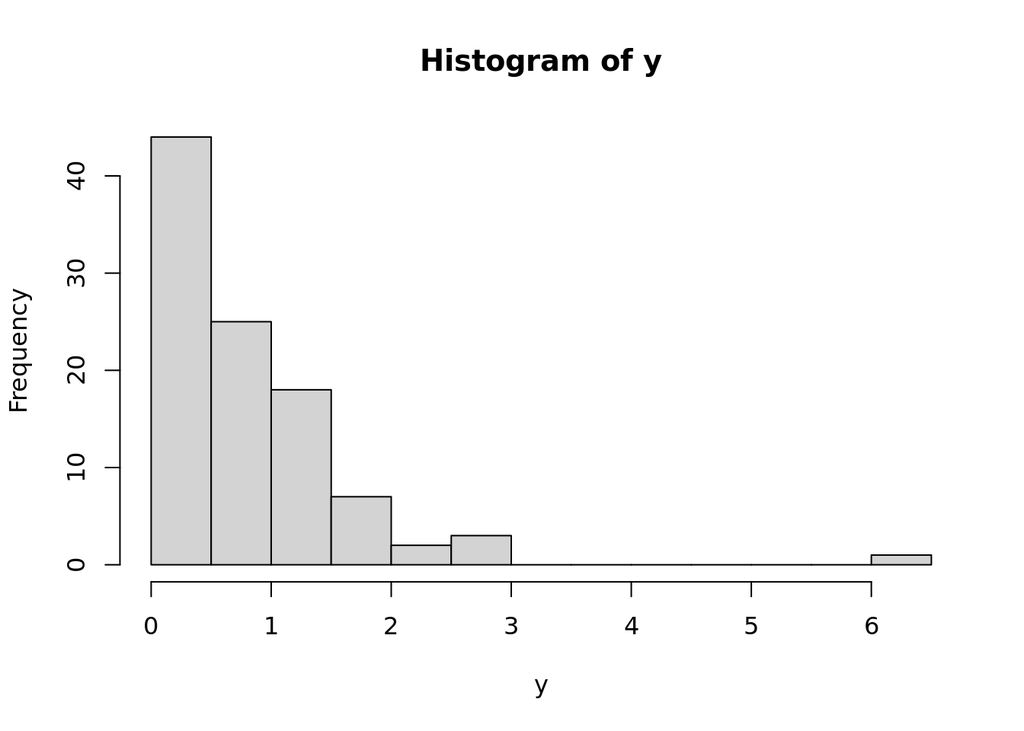

```r
y <- rgamma(100, shape=1)

hist(y, breaks = 20)
```

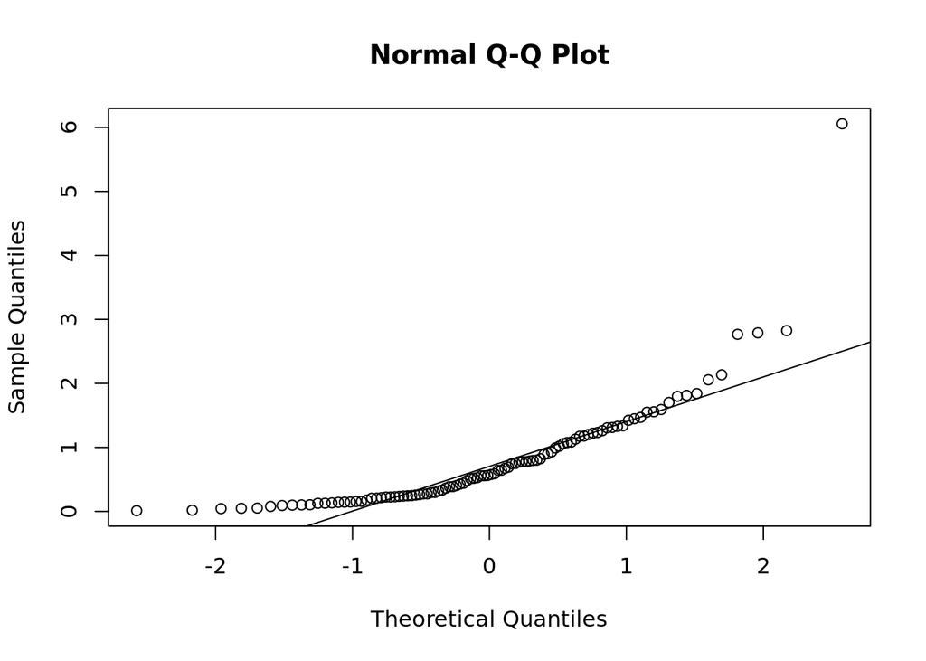

```r
qqnorm(y)
qqline(y)
```

### Multiple plots

We can set up multiple plots with

`par(mfrow=c(#rows, #cols))`

where plots will be placed by row first

or

`par(mfcol=c(#rows, #cols))`

where plots will be placed by column first.

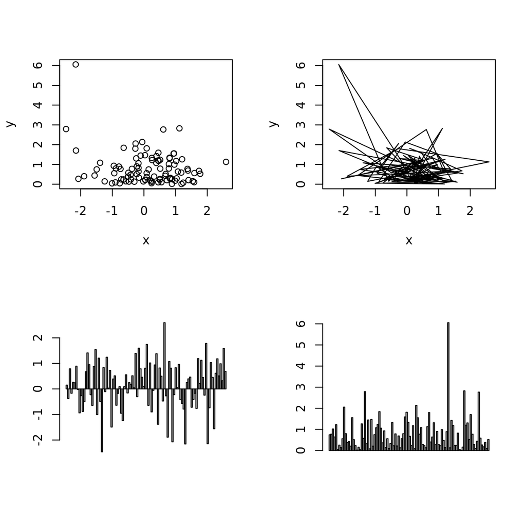

```r
par(mfrow=c(2,2))
  plot(x, y)
  plot(x, y, type="l")
  barplot(x)
  barplot(y)
```

```r
par(mfrow=c(1,1))
```

### Saving plots

Saving a plot involves

- opening a graphics file device using `png` (or `pdf`)
- issuing plot commands
- then closing the device with `dev.off()`.

```r
#create file directory "figs" before running code

png('figs/lm.png')
  m <- lm(y ~ x)
  plot(x, y, col="blue")
  abline(m, col="red", lty="dashed")
dev.off()
```

### Read plot back in

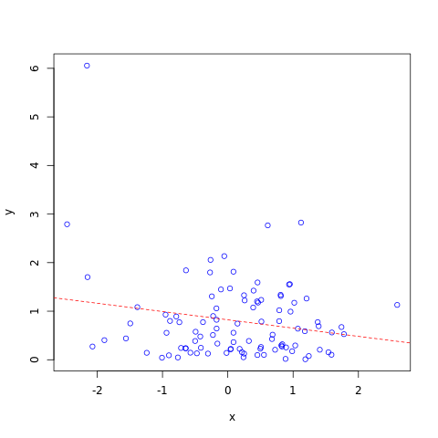

## Exercises

1. Plot a scatter plot of petal width vs petal length from the iris data set. (Recall that in base R, you can access the column for petal width using iris$Petal.Width.)
2. Add a best fit line to the plot.
3. Create a box plot of petal width by species and another box plot of petal length by species. Make these plots sit side-by-side.
4. Create a scatter plot of petal width vs length and color/change symbol by species.
5. Add best fit lines for each species to this plot. Don’t forget to color code the lines. You may also play with changing the line types.
6. Save this scatter plot to a file called “figs/iris.png”.
7. Read the plot file back in and display in the markdown.